# Risk Factor Analysis

## Outcome Variable

**Outcome Variable:** wasted

## Predictor Variables

**Intervention Variable:** predexfd6

**Adjustment Set:**

unadjusted

## Stratifying Variables

The analysis was stratified on these variable(s):

- agecat
- studyid
- country

## Data Summary

| agecat | studyid | country | predexfd6 | wasted | n_cell | n |
| --- | --- | --- | --- | --- | --- | --- |
| Birth | ki0047075b-MAL-ED | BANGLADESH | 1 | 0 | 58 | 194 |
| Birth | ki0047075b-MAL-ED | BANGLADESH | 1 | 1 | 10 | 194 |
| Birth | ki0047075b-MAL-ED | BANGLADESH | 0 | 0 | 102 | 194 |
| Birth | ki0047075b-MAL-ED | BANGLADESH | 0 | 1 | 24 | 194 |
| Birth | ki0047075b-MAL-ED | BRAZIL | 1 | 0 | 5 | 57 |
| Birth | ki0047075b-MAL-ED | BRAZIL | 1 | 1 | 0 | 57 |
| Birth | ki0047075b-MAL-ED | BRAZIL | 0 | 0 | 50 | 57 |
| Birth | ki0047075b-MAL-ED | BRAZIL | 0 | 1 | 2 | 57 |
| Birth | ki0047075b-MAL-ED | INDIA | 1 | 0 | 4 | 37 |
| Birth | ki0047075b-MAL-ED | INDIA | 1 | 1 | 0 | 37 |
| Birth | ki0047075b-MAL-ED | INDIA | 0 | 0 | 28 | 37 |
| Birth | ki0047075b-MAL-ED | INDIA | 0 | 1 | 5 | 37 |
| Birth | ki0047075b-MAL-ED | NEPAL | 1 | 0 | 3 | 23 |
| Birth | ki0047075b-MAL-ED | NEPAL | 1 | 1 | 0 | 23 |
| Birth | ki0047075b-MAL-ED | NEPAL | 0 | 0 | 19 | 23 |
| Birth | ki0047075b-MAL-ED | NEPAL | 0 | 1 | 1 | 23 |
| Birth | ki0047075b-MAL-ED | PERU | 1 | 0 | 71 | 208 |
| Birth | ki0047075b-MAL-ED | PERU | 1 | 1 | 1 | 208 |
| Birth | ki0047075b-MAL-ED | PERU | 0 | 0 | 132 | 208 |
| Birth | ki0047075b-MAL-ED | PERU | 0 | 1 | 4 | 208 |
| Birth | ki0047075b-MAL-ED | SOUTH AFRICA | 1 | 0 | 1 | 90 |
| Birth | ki0047075b-MAL-ED | SOUTH AFRICA | 1 | 1 | 0 | 90 |
| Birth | ki0047075b-MAL-ED | SOUTH AFRICA | 0 | 0 | 80 | 90 |
| Birth | ki0047075b-MAL-ED | SOUTH AFRICA | 0 | 1 | 9 | 90 |
| Birth | ki0047075b-MAL-ED | TANZANIA, UNITED REPUBLIC OF | 1 | 0 | 0 | 105 |
| Birth | ki0047075b-MAL-ED | TANZANIA, UNITED REPUBLIC OF | 1 | 1 | 0 | 105 |
| Birth | ki0047075b-MAL-ED | TANZANIA, UNITED REPUBLIC OF | 0 | 0 | 104 | 105 |
| Birth | ki0047075b-MAL-ED | TANZANIA, UNITED REPUBLIC OF | 0 | 1 | 1 | 105 |
| Birth | ki1000108-CMC-V-BCS-2002 | INDIA | 1 | 0 | 7 | 7 |
| Birth | ki1000108-CMC-V-BCS-2002 | INDIA | 1 | 1 | 0 | 7 |

[output cut: 170 more lines]

The following strata were considered:

- agecat: 24 months, studyid: ki0047075b-MAL-ED, country: BANGLADESH
- agecat: 24 months, studyid: ki0047075b-MAL-ED, country: BRAZIL
- agecat: 24 months, studyid: ki0047075b-MAL-ED, country: INDIA
- agecat: 24 months, studyid: ki0047075b-MAL-ED, country: NEPAL
- agecat: 24 months, studyid: ki0047075b-MAL-ED, country: PERU
- agecat: 24 months, studyid: ki0047075b-MAL-ED, country: SOUTH AFRICA
- agecat: 24 months, studyid: ki0047075b-MAL-ED, country: TANZANIA, UNITED REPUBLIC OF
- agecat: 24 months, studyid: ki1000108-CMC-V-BCS-2002, country: INDIA
- agecat: 24 months, studyid: ki1000108-IRC, country: INDIA
- agecat: 24 months, studyid: ki1000109-EE, country: PAKISTAN
- agecat: 24 months, studyid: ki1017093b-PROVIDE, country: BANGLADESH
- agecat: 24 months, studyid: ki1101329-Keneba, country: GAMBIA
- agecat: 24 months, studyid: ki1113344-GMS-Nepal, country: NEPAL
- agecat: 24 months, studyid: ki1148112-LCNI-5, country: MALAWI
- agecat: 24 months, studyid: kiGH5241-JiVitA-3, country: BANGLADESH
- agecat: 24 months, studyid: kiGH5241-JiVitA-4, country: BANGLADESH
- agecat: 6 months, studyid: ki0047075b-MAL-ED, country: BANGLADESH
- agecat: 6 months, studyid: ki0047075b-MAL-ED, country: BRAZIL
- agecat: 6 months, studyid: ki0047075b-MAL-ED, country: INDIA
- agecat: 6 months, studyid: ki0047075b-MAL-ED, country: NEPAL
- agecat: 6 months, studyid: ki0047075b-MAL-ED, country: PERU
- agecat: 6 months, studyid: ki0047075b-MAL-ED, country: SOUTH AFRICA
- agecat: 6 months, studyid: ki0047075b-MAL-ED, country: TANZANIA, UNITED REPUBLIC OF
- agecat: 6 months, studyid: ki1000108-CMC-V-BCS-2002, country: INDIA
- agecat: 6 months, studyid: ki1000108-IRC, country: INDIA
- agecat: 6 months, studyid: ki1000109-EE, country: PAKISTAN
- agecat: 6 months, studyid: ki1000304b-SAS-CompFeed, country: INDIA
- agecat: 6 months, studyid: ki1000304b-SAS-FoodSuppl, country: INDIA
- agecat: 6 months, studyid: ki1017093b-PROVIDE, country: BANGLADESH
- agecat: 6 months, studyid: ki1101329-Keneba, country: GAMBIA
- agecat: 6 months, studyid: ki1113344-GMS-Nepal, country: NEPAL
- agecat: 6 months, studyid: ki1148112-LCNI-5, country: MALAWI
- agecat: 6 months, studyid: kiGH5241-JiVitA-3, country: BANGLADESH
- agecat: 6 months, studyid: kiGH5241-JiVitA-4, country: BANGLADESH
- agecat: Birth, studyid: ki0047075b-MAL-ED, country: BANGLADESH
- agecat: Birth, studyid: ki0047075b-MAL-ED, country: BRAZIL
- agecat: Birth, studyid: ki0047075b-MAL-ED, country: INDIA
- agecat: Birth, studyid: ki0047075b-MAL-ED, country: NEPAL
- agecat: Birth, studyid: ki0047075b-MAL-ED, country: PERU
- agecat: Birth, studyid: ki0047075b-MAL-ED, country: SOUTH AFRICA
- agecat: Birth, studyid: ki0047075b-MAL-ED, country: TANZANIA, UNITED REPUBLIC OF
- agecat: Birth, studyid: ki1000108-CMC-V-BCS-2002, country: INDIA
- agecat: Birth, studyid: ki1000108-IRC, country: INDIA
- agecat: Birth, studyid: ki1000109-EE, country: PAKISTAN
- agecat: Birth, studyid: ki1000304b-SAS-CompFeed, country: INDIA
- agecat: Birth, studyid: ki1017093b-PROVIDE, country: BANGLADESH
- agecat: Birth, studyid: ki1101329-Keneba, country: GAMBIA
- agecat: Birth, studyid: ki1113344-GMS-Nepal, country: NEPAL
- agecat: Birth, studyid: kiGH5241-JiVitA-3, country: BANGLADESH
- agecat: Birth, studyid: kiGH5241-JiVitA-4, country: BANGLADESH

### Dropped Strata

Some strata were dropped due to rare outcomes:

- agecat: Birth, studyid: ki0047075b-MAL-ED, country: BRAZIL
- agecat: Birth, studyid: ki0047075b-MAL-ED, country: INDIA
- agecat: Birth, studyid: ki0047075b-MAL-ED, country: NEPAL
- agecat: Birth, studyid: ki0047075b-MAL-ED, country: PERU
- agecat: Birth, studyid: ki0047075b-MAL-ED, country: SOUTH AFRICA
- agecat: Birth, studyid: ki0047075b-MAL-ED, country: TANZANIA, UNITED REPUBLIC OF
- agecat: Birth, studyid: ki1000108-CMC-V-BCS-2002, country: INDIA
- agecat: Birth, studyid: ki1000108-IRC, country: INDIA
- agecat: Birth, studyid: ki1000109-EE, country: PAKISTAN
- agecat: Birth, studyid: ki1000304b-SAS-CompFeed, country: INDIA
- agecat: 6 months, studyid: ki0047075b-MAL-ED, country: BANGLADESH
- agecat: 6 months, studyid: ki0047075b-MAL-ED, country: BRAZIL
- agecat: 6 months, studyid: ki0047075b-MAL-ED, country: INDIA
- agecat: 6 months, studyid: ki0047075b-MAL-ED, country: NEPAL
- agecat: 6 months, studyid: ki0047075b-MAL-ED, country: PERU
- agecat: 6 months, studyid: ki0047075b-MAL-ED, country: SOUTH AFRICA
- agecat: 6 months, studyid: ki0047075b-MAL-ED, country: TANZANIA, UNITED REPUBLIC OF
- agecat: 6 months, studyid: ki1000108-CMC-V-BCS-2002, country: INDIA
- agecat: 6 months, studyid: ki1000108-IRC, country: INDIA
- agecat: 6 months, studyid: ki1000109-EE, country: PAKISTAN
- agecat: 6 months, studyid: ki1000304b-SAS-CompFeed, country: INDIA
- agecat: 6 months, studyid: ki1000304b-SAS-FoodSuppl, country: INDIA
- agecat: 6 months, studyid: ki1017093b-PROVIDE, country: BANGLADESH
- agecat: 6 months, studyid: ki1148112-LCNI-5, country: MALAWI
- agecat: 24 months, studyid: ki0047075b-MAL-ED, country: BRAZIL
- agecat: 24 months, studyid: ki0047075b-MAL-ED, country: INDIA
- agecat: 24 months, studyid: ki0047075b-MAL-ED, country: NEPAL
- agecat: 24 months, studyid: ki0047075b-MAL-ED, country: PERU
- agecat: 24 months, studyid: ki0047075b-MAL-ED, country: SOUTH AFRICA
- agecat: 24 months, studyid: ki0047075b-MAL-ED, country: TANZANIA, UNITED REPUBLIC OF
- agecat: 24 months, studyid: ki1000108-CMC-V-BCS-2002, country: INDIA
- agecat: 24 months, studyid: ki1000108-IRC, country: INDIA
- agecat: 24 months, studyid: ki1000109-EE, country: PAKISTAN
- agecat: 24 months, studyid: ki1148112-LCNI-5, country: MALAWI

## Methods Detail

We’re interested in the causal parameters $E[Y_a]$ for all values of $a \in \mathcal{A}$. These parameters represent the mean outcome if, possibly contrary to fact, we intervened to set all units to have $A=a$. Under the randomization and positivity assumptions, these are identified by the statistical parameters $\psi_a=E_W[E_{Y|A,W}(Y|A=a,W)]$. In addition, we’re interested in the mean of $Y$, $E[Y]$ under no intervention (the observed mean). We will estimate these parameters by using SuperLearner to fit the relevant likelihood factors – $E_{Y|A,W}(Y|A=a,W)$ and $p(A=a|W)$, and then updating our likelihood fit using a joint TMLE.

For unadjusted analyses ($W=\{\}$), initial likelihoods were estimated using Lrnr_glm to estimate the simple $E(Y|A)$ and Lrnr_mean to estimate $p(A)$. For adjusted analyses, a small library containing Lrnr_glmnet, Lrnr_xgboost, and Lrnr_mean was used.

Having estimated these parameters, we will then use the delta method to estimate relative risks and attributable risks relative to a prespecified baseline level of $A$.

# Results Detail

## Results Plots

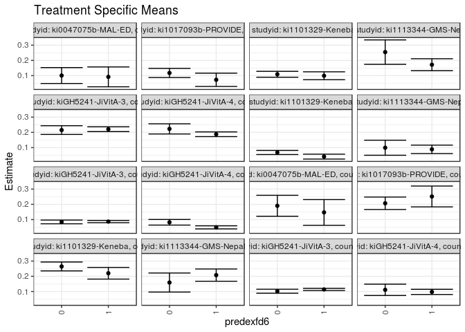

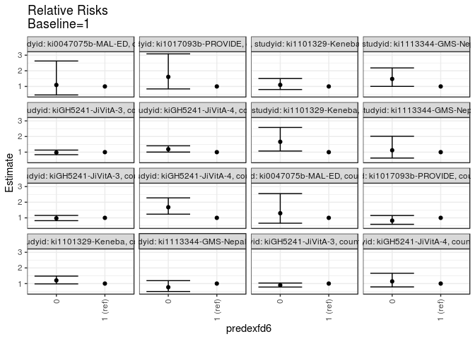

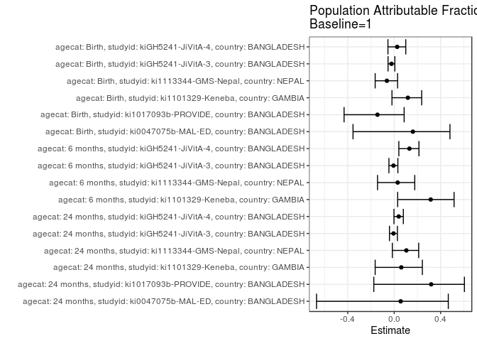

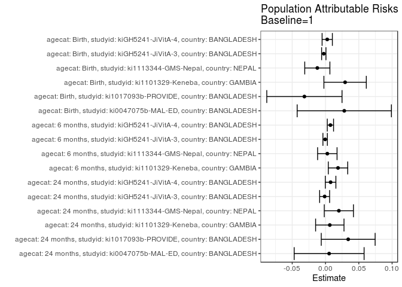

## Results Table

### Parameter: TSM

| agecat | studyid | country | intervention_level | baseline_level | estimate | ci_lower | ci_upper |
| --- | --- | --- | --- | --- | --- | --- | --- |
| Birth | ki0047075b-MAL-ED | BANGLADESH | 1 | NA | 0.1470588 | 0.0626630 | 0.2314546 |
| Birth | ki0047075b-MAL-ED | BANGLADESH | 0 | NA | 0.1904762 | 0.1217345 | 0.2592179 |
| Birth | ki1017093b-PROVIDE | BANGLADESH | 1 | NA | 0.2516129 | 0.1832343 | 0.3199915 |
| Birth | ki1017093b-PROVIDE | BANGLADESH | 0 | NA | 0.2068966 | 0.1659679 | 0.2478252 |
| Birth | ki1101329-Keneba | GAMBIA | 1 | NA | 0.2200000 | 0.1817119 | 0.2582881 |
| Birth | ki1101329-Keneba | GAMBIA | 0 | NA | 0.2645382 | 0.2353346 | 0.2937418 |
| Birth | ki1113344-GMS-Nepal | NEPAL | 1 | NA | 0.2076923 | 0.1673938 | 0.2479908 |
| Birth | ki1113344-GMS-Nepal | NEPAL | 0 | NA | 0.1590909 | 0.0966348 | 0.2215470 |
| Birth | kiGH5241-JiVitA-3 | BANGLADESH | 1 | NA | 0.1137989 | 0.1065928 | 0.1210049 |
| Birth | kiGH5241-JiVitA-3 | BANGLADESH | 0 | NA | 0.1020408 | 0.0889920 | 0.1150897 |
| Birth | kiGH5241-JiVitA-4 | BANGLADESH | 1 | NA | 0.0976693 | 0.0806594 | 0.1146791 |
| Birth | kiGH5241-JiVitA-4 | BANGLADESH | 0 | NA | 0.1113744 | 0.0741972 | 0.1485516 |
| 6 months | ki1101329-Keneba | GAMBIA | 1 | NA | 0.0409556 | 0.0249051 | 0.0570062 |
| 6 months | ki1101329-Keneba | GAMBIA | 0 | NA | 0.0680787 | 0.0544974 | 0.0816600 |
| 6 months | ki1113344-GMS-Nepal | NEPAL | 1 | NA | 0.0886700 | 0.0609936 | 0.1163463 |
| 6 months | ki1113344-GMS-Nepal | NEPAL | 0 | NA | 0.0992908 | 0.0498844 | 0.1486971 |
| 6 months | kiGH5241-JiVitA-3 | BANGLADESH | 1 | NA | 0.0869508 | 0.0795981 | 0.0943035 |
| 6 months | kiGH5241-JiVitA-3 | BANGLADESH | 0 | NA | 0.0846256 | 0.0723420 | 0.0969092 |
| 6 months | kiGH5241-JiVitA-4 | BANGLADESH | 1 | NA | 0.0489931 | 0.0388650 | 0.0591212 |
| 6 months | kiGH5241-JiVitA-4 | BANGLADESH | 0 | NA | 0.0822785 | 0.0638659 | 0.1006911 |
| 24 months | ki0047075b-MAL-ED | BANGLADESH | 1 | NA | 0.0921053 | 0.0269330 | 0.1572776 |
| 24 months | ki0047075b-MAL-ED | BANGLADESH | 0 | NA | 0.1007752 | 0.0487006 | 0.1528498 |
| 24 months | ki1017093b-PROVIDE | BANGLADESH | 1 | NA | 0.0729927 | 0.0293969 | 0.1165885 |
| 24 months | ki1017093b-PROVIDE | BANGLADESH | 0 | NA | 0.1176471 | 0.0875846 | 0.1477095 |
| 24 months | ki1101329-Keneba | GAMBIA | 1 | NA | 0.0992218 | 0.0733681 | 0.1250755 |
| 24 months | ki1101329-Keneba | GAMBIA | 0 | NA | 0.1090000 | 0.0896784 | 0.1283216 |
| 24 months | ki1113344-GMS-Nepal | NEPAL | 1 | NA | 0.1718310 | 0.1325477 | 0.2111143 |
| 24 months | ki1113344-GMS-Nepal | NEPAL | 0 | NA | 0.2543860 | 0.1743541 | 0.3344178 |
| 24 months | kiGH5241-JiVitA-3 | BANGLADESH | 1 | NA | 0.2207726 | 0.2050521 | 0.2364930 |
| 24 months | kiGH5241-JiVitA-3 | BANGLADESH | 0 | NA | 0.2150259 | 0.1864267 | 0.2436252 |
| 24 months | kiGH5241-JiVitA-4 | BANGLADESH | 1 | NA | 0.1876144 | 0.1722075 | 0.2030213 |
| 24 months | kiGH5241-JiVitA-4 | BANGLADESH | 0 | NA | 0.2229581 | 0.1895334 | 0.2563827 |

### Parameter: E(Y)

| agecat | studyid | country | intervention_level | baseline_level | estimate | ci_lower | ci_upper |
| --- | --- | --- | --- | --- | --- | --- | --- |
| Birth | ki0047075b-MAL-ED | BANGLADESH | NA | NA | 0.1752577 | 0.1216204 | 0.2288951 |
| Birth | ki1017093b-PROVIDE | BANGLADESH | NA | NA | 0.2199248 | 0.1846953 | 0.2551543 |
| Birth | ki1101329-Keneba | GAMBIA | NA | NA | 0.2494348 | 0.2261459 | 0.2727237 |
| Birth | ki1113344-GMS-Nepal | NEPAL | NA | NA | 0.1954023 | 0.1613549 | 0.2294497 |
| Birth | kiGH5241-JiVitA-3 | BANGLADESH | NA | NA | 0.1112249 | 0.1049045 | 0.1175452 |
| Birth | kiGH5241-JiVitA-4 | BANGLADESH | NA | NA | 0.1002698 | 0.0846581 | 0.1158815 |
| 6 months | ki1101329-Keneba | GAMBIA | NA | NA | 0.0597484 | 0.0491105 | 0.0703864 |
| 6 months | ki1113344-GMS-Nepal | NEPAL | NA | NA | 0.0914077 | 0.0672348 | 0.1155805 |
| 6 months | kiGH5241-JiVitA-3 | BANGLADESH | NA | NA | 0.0864198 | 0.0802086 | 0.0926309 |
| 6 months | kiGH5241-JiVitA-4 | BANGLADESH | NA | NA | 0.0563743 | 0.0475411 | 0.0652074 |
| 24 months | ki0047075b-MAL-ED | BANGLADESH | NA | NA | 0.0975610 | 0.0568436 | 0.1382784 |
| 24 months | ki1017093b-PROVIDE | BANGLADESH | NA | NA | 0.1070812 | 0.0818727 | 0.1322897 |
| 24 months | ki1101329-Keneba | GAMBIA | NA | NA | 0.1056803 | 0.0901896 | 0.1211711 |
| 24 months | ki1113344-GMS-Nepal | NEPAL | NA | NA | 0.1918977 | 0.1562203 | 0.2275751 |
| 24 months | kiGH5241-JiVitA-3 | BANGLADESH | NA | NA | 0.2194592 | 0.2057462 | 0.2331723 |
| 24 months | kiGH5241-JiVitA-4 | BANGLADESH | NA | NA | 0.1952677 | 0.1809764 | 0.2095589 |

### Parameter: RR

| agecat | studyid | country | intervention_level | baseline_level | estimate | ci_lower | ci_upper |
| --- | --- | --- | --- | --- | --- | --- | --- |
| Birth | ki0047075b-MAL-ED | BANGLADESH | 1 | 1 | 1.0000000 | 1.0000000 | 1.000000 |
| Birth | ki0047075b-MAL-ED | BANGLADESH | 0 | 1 | 1.2952381 | 0.6575460 | 2.551368 |
| Birth | ki1017093b-PROVIDE | BANGLADESH | 1 | 1 | 1.0000000 | 1.0000000 | 1.000000 |
| Birth | ki1017093b-PROVIDE | BANGLADESH | 0 | 1 | 0.8222812 | 0.5875410 | 1.150807 |
| Birth | ki1101329-Keneba | GAMBIA | 1 | 1 | 1.0000000 | 1.0000000 | 1.000000 |
| Birth | ki1101329-Keneba | GAMBIA | 0 | 1 | 1.2024464 | 0.9784960 | 1.477653 |
| Birth | ki1113344-GMS-Nepal | NEPAL | 1 | 1 | 1.0000000 | 1.0000000 | 1.000000 |
| Birth | ki1113344-GMS-Nepal | NEPAL | 0 | 1 | 0.7659933 | 0.4943584 | 1.186883 |
| Birth | kiGH5241-JiVitA-3 | BANGLADESH | 1 | 1 | 1.0000000 | 1.0000000 | 1.000000 |
| Birth | kiGH5241-JiVitA-3 | BANGLADESH | 0 | 1 | 0.8966770 | 0.7776591 | 1.033910 |
| Birth | kiGH5241-JiVitA-4 | BANGLADESH | 1 | 1 | 1.0000000 | 1.0000000 | 1.000000 |
| Birth | kiGH5241-JiVitA-4 | BANGLADESH | 0 | 1 | 1.1403220 | 0.7850997 | 1.656266 |
| 6 months | ki1101329-Keneba | GAMBIA | 1 | 1 | 1.0000000 | 1.0000000 | 1.000000 |
| 6 months | ki1101329-Keneba | GAMBIA | 0 | 1 | 1.6622540 | 1.0708152 | 2.580360 |
| 6 months | ki1113344-GMS-Nepal | NEPAL | 1 | 1 | 1.0000000 | 1.0000000 | 1.000000 |
| 6 months | ki1113344-GMS-Nepal | NEPAL | 0 | 1 | 1.1197794 | 0.6223492 | 2.014794 |
| 6 months | kiGH5241-JiVitA-3 | BANGLADESH | 1 | 1 | 1.0000000 | 1.0000000 | 1.000000 |
| 6 months | kiGH5241-JiVitA-3 | BANGLADESH | 0 | 1 | 0.9732583 | 0.8199416 | 1.155243 |
| 6 months | kiGH5241-JiVitA-4 | BANGLADESH | 1 | 1 | 1.0000000 | 1.0000000 | 1.000000 |
| 6 months | kiGH5241-JiVitA-4 | BANGLADESH | 0 | 1 | 1.6793896 | 1.2373619 | 2.279324 |
| 24 months | ki0047075b-MAL-ED | BANGLADESH | 1 | 1 | 1.0000000 | 1.0000000 | 1.000000 |
| 24 months | ki0047075b-MAL-ED | BANGLADESH | 0 | 1 | 1.0941307 | 0.4555621 | 2.627791 |
| 24 months | ki1017093b-PROVIDE | BANGLADESH | 1 | 1 | 1.0000000 | 1.0000000 | 1.000000 |
| 24 months | ki1017093b-PROVIDE | BANGLADESH | 0 | 1 | 1.6117647 | 0.8417271 | 3.086256 |
| 24 months | ki1101329-Keneba | GAMBIA | 1 | 1 | 1.0000000 | 1.0000000 | 1.000000 |
| 24 months | ki1101329-Keneba | GAMBIA | 0 | 1 | 1.0985490 | 0.8015931 | 1.505514 |
| 24 months | ki1113344-GMS-Nepal | NEPAL | 1 | 1 | 1.0000000 | 1.0000000 | 1.000000 |
| 24 months | ki1113344-GMS-Nepal | NEPAL | 0 | 1 | 1.4804429 | 1.0034471 | 2.184182 |
| 24 months | kiGH5241-JiVitA-3 | BANGLADESH | 1 | 1 | 1.0000000 | 1.0000000 | 1.000000 |
| 24 months | kiGH5241-JiVitA-3 | BANGLADESH | 0 | 1 | 0.9739702 | 0.8370443 | 1.133295 |
| 24 months | kiGH5241-JiVitA-4 | BANGLADESH | 1 | 1 | 1.0000000 | 1.0000000 | 1.000000 |
| 24 months | kiGH5241-JiVitA-4 | BANGLADESH | 0 | 1 | 1.1883846 | 1.0039776 | 1.406663 |

### Parameter: PAR

| agecat | studyid | country | intervention_level | baseline_level | estimate | ci_lower | ci_upper |
| --- | --- | --- | --- | --- | --- | --- | --- |
| Birth | ki0047075b-MAL-ED | BANGLADESH | 1 | NA | 0.0281989 | -0.0425571 | 0.0989549 |
| Birth | ki1017093b-PROVIDE | BANGLADESH | 1 | NA | -0.0316881 | -0.0881879 | 0.0248117 |
| Birth | ki1101329-Keneba | GAMBIA | 1 | NA | 0.0294348 | -0.0024100 | 0.0612797 |
| Birth | ki1113344-GMS-Nepal | NEPAL | 1 | NA | -0.0122900 | -0.0311731 | 0.0065930 |
| Birth | kiGH5241-JiVitA-3 | BANGLADESH | 1 | NA | -0.0025740 | -0.0058359 | 0.0006879 |
| Birth | kiGH5241-JiVitA-4 | BANGLADESH | 1 | NA | 0.0026005 | -0.0051023 | 0.0103034 |
| 6 months | ki1101329-Keneba | GAMBIA | 1 | NA | 0.0187928 | 0.0042140 | 0.0333716 |
| 6 months | ki1113344-GMS-Nepal | NEPAL | 1 | NA | 0.0027377 | -0.0118650 | 0.0173404 |
| 6 months | kiGH5241-JiVitA-3 | BANGLADESH | 1 | NA | -0.0005311 | -0.0038690 | 0.0028068 |
| 6 months | kiGH5241-JiVitA-4 | BANGLADESH | 1 | NA | 0.0073812 | 0.0026772 | 0.0120852 |
| 24 months | ki0047075b-MAL-ED | BANGLADESH | 1 | NA | 0.0054557 | -0.0470421 | 0.0579535 |
| 24 months | ki1017093b-PROVIDE | BANGLADESH | 1 | NA | 0.0340885 | -0.0063670 | 0.0745439 |
| 24 months | ki1101329-Keneba | GAMBIA | 1 | NA | 0.0064585 | -0.0148611 | 0.0277781 |
| 24 months | ki1113344-GMS-Nepal | NEPAL | 1 | NA | 0.0200667 | -0.0018400 | 0.0419733 |
| 24 months | kiGH5241-JiVitA-3 | BANGLADESH | 1 | NA | -0.0013133 | -0.0088009 | 0.0061743 |
| 24 months | kiGH5241-JiVitA-4 | BANGLADESH | 1 | NA | 0.0076533 | -0.0002738 | 0.0155804 |

### Parameter: PAF

| agecat | studyid | country | intervention_level | baseline_level | estimate | ci_lower | ci_upper |
| --- | --- | --- | --- | --- | --- | --- | --- |
| Birth | ki0047075b-MAL-ED | BANGLADESH | 1 | NA | 0.1608997 | -0.3544668 | 0.4801723 |
| Birth | ki1017093b-PROVIDE | BANGLADESH | 1 | NA | -0.1440860 | -0.4316602 | 0.0857238 |
| Birth | ki1101329-Keneba | GAMBIA | 1 | NA | 0.1180060 | -0.0191368 | 0.2366939 |
| Birth | ki1113344-GMS-Nepal | NEPAL | 1 | NA | -0.0628959 | -0.1637323 | 0.0292031 |
| Birth | kiGH5241-JiVitA-3 | BANGLADESH | 1 | NA | -0.0231422 | -0.0528799 | 0.0057557 |
| Birth | kiGH5241-JiVitA-4 | BANGLADESH | 1 | NA | 0.0259353 | -0.0538619 | 0.0996903 |
| 6 months | ki1101329-Keneba | GAMBIA | 1 | NA | 0.3145320 | 0.0298959 | 0.5156537 |
| 6 months | ki1113344-GMS-Nepal | NEPAL | 1 | NA | 0.0299507 | -0.1435240 | 0.1771091 |
| 6 months | kiGH5241-JiVitA-3 | BANGLADESH | 1 | NA | -0.0061452 | -0.0454751 | 0.0317052 |
| 6 months | kiGH5241-JiVitA-4 | BANGLADESH | 1 | NA | 0.1309318 | 0.0399722 | 0.2132732 |
| 24 months | ki0047075b-MAL-ED | BANGLADESH | 1 | NA | 0.0559211 | -0.6686320 | 0.4658588 |
| 24 months | ki1017093b-PROVIDE | BANGLADESH | 1 | NA | 0.3183424 | -0.1756416 | 0.6047629 |
| 24 months | ki1101329-Keneba | GAMBIA | 1 | NA | 0.0611138 | -0.1637440 | 0.2425248 |
| 24 months | ki1113344-GMS-Nepal | NEPAL | 1 | NA | 0.1045696 | -0.0161000 | 0.2109088 |
| 24 months | kiGH5241-JiVitA-3 | BANGLADESH | 1 | NA | -0.0059844 | -0.0406845 | 0.0275587 |
| 24 months | kiGH5241-JiVitA-4 | BANGLADESH | 1 | NA | 0.0391938 | -0.0019846 | 0.0786799 |